# PINP Code for seabird detection in fur seal diets

Natasha Hardy

25/02/2021

## About

**Citation:** MS in prep. Add citation after submission.

This document contains all code pertinent to figures and analyses presented in this publication: (i) data manipulation, (ii) data analyses and (iii) visualisations for the seabird detection in long-nosed fur seal diet project.

## Workspace

```r
#Check working directory - the same as the doc directory.

#getwd()

#Install Packages as needed
#install.packages("rcompanion")

#Load
library(tidyverse)
library(tidyr)
library(tidytext)
#library(reshape)
library(plyr)
library(dplyr)
library(PNWColors)
library(lattice)
library(reshape2)
library(lme4)
library(ggplot2)
library(rcompanion)
library(gg.gap)
library(forcats)
library(devtools)
library(cowplot)
library(grid)
library(gridExtra)
library(scales)
library(ggpubr)
library(here)
"%notin%" = Negate('%in%')
here::here()

#Note that loading all these packages is hell because of overlap in functions, some packages being superceded but still requiring each other or requiring functions from one package to another. You'll notice I had to force a lot of functions by calling the package as follows
#data %>% package::function(etc). I'm sure there are more talented and savvy coders than me who can figure this out more elegantly.
```

## Load data

These dataframes are currently downloaded as .csv spreadsheets from the diet analysis master document found here: [PINP Bird Data](https://docs.google.com/spreadsheets/d/1phfyo3kUyWZfwKF0IAHXgkxy23dbYs_tKkCfEIWeY8g/edit#gid=2115650924)

**NOTE:** we want to clean this up and include the whole spreadsheet and read these in as tabs.

```r
#0 = "hp_taxa" tab
hp_taxa_export <- read.csv(here("data/input_data/hp_taxa.csv"), header=TRUE)

#1 = "bird_detect_med" tab
bird_wide_med <- read.csv(here("data/input_data/bird_detect_med.csv"), header=TRUE)

#2 = "bird_detect_high" tab
bird_wide_high <- read.csv(here("data/input_data/bird_detect_high.csv"), header=TRUE)

#3 = "penguin_detect_med" tab
penguin_wide_med <- read.csv(here("data/input_data/penguin_detect_med.csv"), header=TRUE)

#4 = "penguin_detect_high" tab
penguin_wide_high <- read.csv(here("data/input_data/penguin_detect_high.csv"), header=TRUE)

#5 = "otu_med" tab
otu_med_export <- read.csv(here("data/input_data/otu_med.csv"), header=TRUE)

#6 = "otu_high" tab
otu_high_export <- read.csv(here("data/input_data/otu_high.csv"), header=TRUE)

#7 penguin haplotypes
penguin_haplos_export <- read.csv(here("data/input_data/penguin_haplos.csv"), header=TRUE)
```

## Data manipulations

Here we mainly clean column or variable names, gather wide data and change to longform. I originally chose to input data as columns in the master document tab “BIRD_DATA” in PINP_BIRD_DATA.xlsx on GoogleDrive. This is because many columns were calculated based off other columns (such as medium stringency DNA OTU total abundance used to calculate a 1% cut-off for high stringency DNA OTU columns). This means a little data wrangling on this end to merge these data into long-form for analyses and graphing.

For the following manipulations, I’m going to: (i) Rename colnames for each of the four datasets exported, (ii) Transform from wide to long data, using melt(), and include arguments for renaming the output variable and value to “metric” and “detection”, and (iii) Add a categorical descriptor for each method, to later merge datasets 1+2 (bird detections) and 3+4 (penguin detections)

Columns are renamed as follows: hp = hard-part analysis to ID prey dna = DNA metabarcoding to ID prey dna_or_hp = detections using either method same_taxon = both detected the same bird taxon (for bird only, as “both” and “same” are equal for looking at one taxon such as penguins) Note, I have removed “both_methods = both detected birds/penguins”. This column was confusing and did not add information, it was originally to report the number of samples that contained different taxa identified from the same taxa using both methods.

Then add descriptor: medium = standard QC for DNA based analysis high = additional exclusion of trace amounts of DNA that passed QC

Note on 22nd March 2020, I corrected a mistake in an excel function for the penguin datasets, that had effectively inputted some wrong numbers in the penguin detection columns. I have rerun analyses and updated stats, and figures.

```r
hp_taxa = hp_taxa_export %>%
  dplyr::rename(`E. minor` = `SUM.of.penguin_hp`,
                Procellarid = `SUM.of.procellarid_hp`,
                `M. serrator` = `SUM.of.gannet_hp`,
                `Seabird unknown` = `SUM.of.unknown_hp`) %>%
  #Renamed columns
  reshape2::melt(id.vars=c("sample_id", "location_id", "location", "time_id", "group_id"), variable.name = "Taxa", value.name = "detect") %>%
  #Transform wide to long data, using melt(), and added arguments for renaming the output variable and value to "metric" and "detection"
  #Added the character vector/factor for merging with the high stringency data
  mutate(method = "hard-parts")

#Rename factor levels
hp_taxa$location <- factor(hp_taxa$location,
                           levels = c("Cape Bridgewater", "Gabo Island", "Lady Julia Percy", "Montague Island"),
                           labels = c("Cape Bridgewater", "Gabo Island", "Deen Maar", "Barunguba"))

hp_taxa$time_id <- factor(hp_taxa$time_id,
                          levels = c("Sep_15", "Jan_16", "Sep_16", "Jan_17", "Mar_17"),
                          labels = c("Sep'15", "Jan'16", "Sep'16", "Jan'17", "Mar'17"))
```

```r
bird_med = bird_wide_med %>%
  dplyr::rename(hp = `SUM.of.allbirds_hp`, dna = `SUM.of.allbirds_dna_cons`,
                dna_or_hp = `SUM.of.allbirds_cons_dna_or_hp`,
                both_methods = `SUM.of.allbirds_cons_both`,
                same_taxon = `SUM.of.allbirds_cons_sametaxa`) %>%
  #Renamed columns
  dplyr::select(., -both_methods) %>%
  reshape2::melt(id.vars=c("sample_id", "location_id", "location", "time_id", "group_id"), variable.name = "metric", value.name = "detection") %>%
  #Transform wide to long data, using melt(), and added arguments for renaming the output variable and value to "metric" and "detection"
  #Added the character vector/factor for merging with the high stringency data
 mutate(method = if_else(metric == "hp", "hard part", "DNA standard QC"))

#Rename factor levels
bird_med$location <- factor(bird_med$location,
                            levels = c("Cape Bridgewater", "Gabo Island", "Lady Julia Percy", "Montague Island"),
                            labels = c("Cape Bridgewater", "Gabo Island", "Deen Maar", "Barunguba"))

bird_med$time_id <- factor(bird_med$time_id,
                           levels = c("Sep_15", "Jan_16", "Sep_16", "Jan_17", "Mar_17"),
                           labels = c("Sep'15", "Jan'16", "Sep'16", "Jan'17", "Mar'17"))
```

```r
bird_high = bird_wide_high %>%
  dplyr::rename(hp = `SUM.of.allbirds_hp`, dna = `SUM.of.allbirds_dna_high`,
                dna_or_hp = `SUM.of.allbirds_high_dna_or_hp`,
                both_methods = `SUM.of.allbirds_high_both`,
                same_taxon = `SUM.of.allbirds_high_same`) %>%
  #Renamed columns
  dplyr::select(., -both_methods) %>%
  reshape2::melt(id.vars=c("sample_id", "location_id", "location", "time_id", "group_id"), variable.name = "metric", value.name = "detection") %>%
  #Transform wide to long data, using melt(), and added arguments for renaming the output variable and value to "metric" and "detection"
  filter(metric != "hp") %>% #here I'm removing the repeated subset of data on hard-part analysis for graphing
  mutate(method = "DNA stringent QC")

#Rename factor levels
bird_high$location <- factor(bird_high$location,
                             levels = c("Cape Bridgewater", "Gabo Island", "Lady Julia Percy", "Montague Island"),
                             labels = c("Cape Bridgewater", "Gabo Island", "Deen Maar", "Barunguba"))

bird_high$time_id <- factor(bird_high$time_id,
                            levels = c("Sep_15", "Jan_16", "Sep_16", "Jan_17", "Mar_17"),
                            labels = c("Sep'15", "Jan'16", "Sep'16", "Jan'17", "Mar'17"))
```

```r
penguin_med = penguin_wide_med %>%
  dplyr::rename(hp = `SUM.of.penguin_hp`, dna = `SUM.of.penguin_dna_cons`,
                dna_or_hp = `SUM.of.penguin_cons_dna_or_hp`,
                same_taxon = `SUM.of.penguin_cons_both`) %>%
  #Renamed columns
  reshape2::melt(id.vars=c("sample_id", "location_id", "location", "time_id", "group_id"), variable.name = "metric", value.name = "detection") %>%
  #Transform wide to long data, using melt(), and added arguments for renaming the output variable and value to "metric" and "detection"
   mutate(method = if_else(metric == "hp", "hard part", "DNA standard QC"))

#Rename factor levels
penguin_med$location <- factor(penguin_med$location,
                               levels = c("Cape Bridgewater", "Gabo Island", "Lady Julia Percy", "Montague Island"),
                               labels = c("Cape Bridgewater", "Gabo Island", "Deen Maar", "Barunguba"))

penguin_med$time_id <- factor(penguin_med$time_id,
                              levels = c("Sep_15", "Jan_16", "Sep_16", "Jan_17", "Mar_17"),
                              labels = c("Sep'15", "Jan'16", "Sep'16", "Jan'17", "Mar'17"))
```

```r
penguin_high = penguin_wide_high %>%
  dplyr::rename(hp = `SUM.of.penguin_hp`, dna = `SUM.of.penguin_dna_high`,
                dna_or_hp = `SUM.of.penguin_high_dna_or_hp`,
                same_taxon = `SUM.of.penguin_high_both`) %>%
  #Renamed columns
  reshape2::melt(id.vars=c("sample_id", "location_id", "location", "time_id", "group_id"), variable.name = "metric", value.name = "detection") %>%
  #Transform wide to long data, using melt(), and added arguments for renaming the output variable and value to "metric" and "detection"
  #Added the character vector/factor for merging with the high stringency data
  filter(metric != "hp") %>% #here I'm removing the repeated subset of data on hard-part analysis for graphing
  mutate(method = "DNA stringent QC")

#Rename factor levels
penguin_high$location <- factor(penguin_high$location,
                                levels = c("Cape Bridgewater", "Gabo Island", "Lady Julia Percy", "Montague Island"),
                                labels = c("Cape Bridgewater", "Gabo Island", "Deen Maar", "Barunguba"))

penguin_high$time_id <- factor(penguin_high$time_id,
                               levels = c("Sep_15", "Jan_16", "Sep_16", "Jan_17", "Mar_17"),
                               labels = c("Sep'15", "Jan'16", "Sep'16", "Jan'17", "Mar'17"))
```

```r
#OTU_med cleaning

otu_med = otu_med_export %>%
  dplyr::rename(OTU1_E_minor = `SUM.of.cons_OTU_1..Eudyptula.minor.`,
                OTU2_Procellarid1 = `SUM.of.cons_OTU_2..Procellariidae.sp.1.`,
                OTU3_Procellarid2 = `SUM.of.cons_OTU_3..Procellariidae.sp.2.`,
                OTU4_T_melanophris = `SUM.of.cons_OTU_4..Thalassarche.melanophris.`,
                OTU5_S_bergii = `SUM.of.cons_OTU_5..Sterna.bergii.`) %>%
  #Renamed columns
  reshape2::melt(id.vars=c("sample_id", "location_id", "location", "time_id", "group_id"), variable.name = "OTU", value.name = "seq_abun") %>%
  #Transform wide to long data, using melt(), and added arguments for renaming the output variable and value to "metric" and "detection"
  #Added the character vector/factor for merging with the high stringency data
  mutate(method = "DNA standard QC")

#Relative read abundances by taxon / OTU
#Truncating datasets to calculate additional sequence metrics.
mdata1 = otu_med %>%
  filter(OTU == "OTU1_E_minor") %>%
  mutate(seq_prop = seq_abun/sum(seq_abun)*100)
mdata2 = otu_med %>%
  filter(OTU == "OTU2_Procellarid1") %>%
  mutate(seq_prop = seq_abun/sum(seq_abun)*100)
mdata3 = otu_med %>%
  filter(OTU == "OTU3_Procellarid2") %>%
  mutate(seq_prop = seq_abun/sum(seq_abun)*100)
mdata4 = otu_med %>%
  filter(OTU == "OTU4_T_melanophris") %>%
  mutate(seq_prop = seq_abun/sum(seq_abun)*100)
mdata5 = otu_med %>%
  filter(OTU == "OTU5_S_bergii") %>%
  mutate(seq_prop = seq_abun/sum(seq_abun)*100)

#Join these subsetted and manipulated datasets
otu_med_data = rbind(mdata1, mdata2, mdata3, mdata4, mdata5)

#These two are split due to problems knitting the doc
otu_med_data = otu_med_data %>%
  mutate(trace_high = if_else(otu_med_data$seq_abun >= 10, "high", "trace"),
         total_prop = seq_abun/sum(seq_abun)*100) #Add trace vs. high DNA abundance, and proportion of total seq abundance variable #Relative read abundance / total DNA abundance

#Change labels for location
otu_med_data$location <- factor(otu_med_data$location, levels = c("Cape Bridgewater", "Gabo Island", "Lady Julia Percy", "Montague Island"), labels = c("Cape Bridgewater", "GI", "DM", "Barunguba"))
#Change labels for time
otu_med_data$time_id <- factor(otu_med_data$time_id, levels = c("Sep_15", "Jan_16", "Sep_16", "Jan_17", "Mar_17"), labels = c("Sep'15", "Jan'16", "Sep'16", "Jan'17", "Mar'17"))
#Change labels for OTUs
#levels(otu_med_abundant$OTU)
otu_med_data$OTU <- factor(otu_med_data$OTU, levels = c("OTU1_E_minor", "OTU2_Procellarid1", "OTU3_Procellarid2", "OTU4_T_melanophris", "OTU5_S_bergii"), labels = c("E. minor", "Procellarid sp1", "Procellarid sp2", "T. melanophris", "S. bergii"))

otu_med_data$trace_high <- as.factor(otu_med_data$trace_high)

#output = otu_med_data
```

```r
# Created a separate summary df
otu_med_sum <- ddply(otu_med_data, c("location", "time_id", "group_id", "sample_id"), summarise,
                  sample_abun = sum(seq_abun))
# Joined back by sample_id (shared variable)
otu_sampleabun <- merge(x = otu_med_data, y = otu_med_sum, by = c("location", "time_id", "group_id", "sample_id"))

otu_metrics = otu_sampleabun %>%
  select(location:OTU, method, trace_high, seq_abun, sample_abun, seq_prop, total_prop) %>%
  #dplyr::rename(location = `location.x`, time_id = `time_id.x`, group_id = `group_id.x`) %>%
  mutate(prop_abun = if_else(sample_abun >= 1, seq_abun/sample_abun*100, 0))

#output = otu_metrics and supercedes otu_med_data
```

### OTU metric outputs

Note the following output columns: *seq_abun* = absolute sequence abundance for a given taxa within the sample; *sample_abun* = total abundance of sequences obtained within that sample from any taxon; *seq_prop* = proportional sequence abundance for a certain taxon within a sample, as a percent of total sequences belonging to that taxon; *total_prop* = proportional sequence abundance for a certain taxon within a sample as a percent of total sequence abundance; *prop_abun* = proportional sequence abundance for a certain taxon as a percent of total sequences within a sample;

```r
penguin_haplos = penguin_haplos_export %>%
  dplyr::select(-time) %>%
  dplyr::rename(haplo_1 = `SUM.of.haplo_1`,
                haplo_2 = `SUM.of.haplo_2`,
                haplo_3 = `SUM.of.haplo_3`,
                haplo_4 = `SUM.of.haplo_4`,
                haplo_5 = `SUM.of.haplo_5`,
                haplo_6 = `SUM.of.haplo_6`,
                haplo_7 = `SUM.of.haplo_7`) %>%
  #Renamed columns
  reshape2::melt(id.vars=c("sample_id", "location_id", "location", "time_id", "group_id"), variable.name = "haplotype", value.name = "seq_abun") %>%
  mutate(seq_presence = if_else(seq_abun > 0, "1", "0")) %>%
  filter(seq_abun > 1)

penguin_haplos_sample = penguin_haplos %>%
  separate(sample_id, c("loc", "month", "year", "sample"))

penguin_haplos_sample$sample <- as.factor(penguin_haplos_sample$sample)

#output = penguin_haplos_sample
```

## Data outputs - masters & summaries

```r
#Need to join the bird_med and bird_high datasets for graphing

bird_master <- rbind(bird_med, bird_high)
```

```r
#Need to join the penguin_med and penguin_high datasets for graphing

penguin_master <- rbind(penguin_med, penguin_high)
```

```r
#Overall bird detection by method: need to summarise of all samples containing bird by method of detection
#Need to scale to 100%

# Bird master
bird_sum_master <- ddply(bird_master, c("method", "metric"), summarise,
                  `Detected` = sum(detection, na.rm=TRUE)*100/99)

# Penguin master
penguin_sum_master <- ddply(penguin_master, c("method", "metric"), summarise,
                  `Detected` = sum(detection, na.rm=TRUE)*100/99)

#Can double check this with table()
#i.e., table(bird_long$metric, bird_long$value)
```

```r
#Overall detection by location and sampling time
#Here we want to select just the metrics that we want to display and need to scale to 100%

as.factor(bird_master$method)

#0 sampling effort by time / location for Bec:
observations = bird_med %>%
  group_by(location, time_id, group_id, metric) %>%
  dplyr::summarize(obs = n()) %>%
  filter(metric == c('hp')) %>%
  select(location, time_id, group_id, obs)

#write.csv(observations, here("data/output_data/sampling_effort.csv"))
```

```r
#1 Bird detections by location/time
#Summarise
#PROBLEM = how to turn this into a percentage of samples within each location/time?

bird_sum_group = bird_med %>%
  group_by(location, time_id, group_id, metric) %>%
  dplyr::summarize(obs = n(), detected = sum(detection), percentage_detected = (detected/obs*100))

#Take subset for figure
bird_master_group = bird_sum_group %>%
  select(location, time_id, group_id, metric, obs, detected, percentage_detected) %>%
  filter(metric == c('hp', 'dna'))
```

```r
#2 Penguin detections by location/time

#Summarise

penguin_sum_group = penguin_med %>%
  group_by(location, time_id, group_id, metric) %>%
  dplyr::summarize(obs = n(), detected = sum(detection), percentage_detected = (detected/obs*100))

#Take subset for figure
penguin_master_group = penguin_sum_group %>%
  select(location, time_id, group_id, metric, obs, detected, percentage_detected) %>%
  filter(metric == c('hp', 'dna'))
```

```r
#Need to join the penguin_med and penguin_high datasets for graphing

otu_hp_master = otu_metrics %>%
  dplyr::rename(`Taxa` = `OTU`) %>%
  mutate(detect = if_else(seq_abun > 0, 1, 0)) %>%
  full_join(hp_taxa, by= c("sample_id", "location_id", "location", "time_id", "group_id", "method", "Taxa", "detect")) %>%
  separate(sample_id, c("loc", "month", "year", "sample")) %>%
  select(sample, location_id, location, time_id, group_id, Taxa, method, trace_high, seq_abun, sample_abun, seq_prop, total_prop, prop_abun, detect)

#Change order of levels for Taxa

otu_hp_master$Taxa <- factor(otu_hp_master$Taxa, levels = c("E. minor", "Procellarid sp1", "Procellarid sp2", "Procellarid", "T. melanophris", "S. bergii", "M. serrator", "Seabird unknown"))
otu_hp_master$method <- as.factor(otu_hp_master$method)
otu_hp_master$sample <- as.factor(otu_hp_master$sample)
otu_hp_master$detect <- as.integer(otu_hp_master$detect)
```

## MS Figures

**Note on figures in MS:**

- Figure 1 was prepared by Harley at PINP using QGIS software.
- Figure 2 is a composite panel of photos by Natasha Hardy & Rebecca McIntosh.

### Bar plots for MS:

**- Figure 3a** aims to display the proportion of samples detecting seabirds using either hard-part methods, DNA-based methods, both combined or either of those methods.

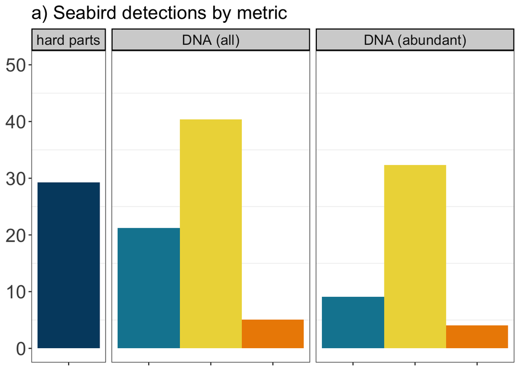

```r
#Figure 3a

#Figure 3 colour palette
fig3.pal <- pnw_palette(5, name = "Bay", type = "continuous")

#Relevel the method so that hard-part method comes first in the graph AND relabel
#levels(bird_sum_master$method) #check levels
bird_sum_master$method <- factor(bird_sum_master$method, levels = c("hard part", "DNA standard QC", "DNA stringent QC"), label = c("hard parts", "DNA (all)", "DNA (abundant)"))

#Relabel to clarify calculations
#levels(bird_sum_master$metric) # check levels
bird_sum_master$metric <- factor(bird_sum_master$metric, levels = c("hp", "dna", "dna_or_hp", "same_taxon"), label = c("hp", "dna", "dna or hp", "same taxon"))

#Figure 3a
fig3a_bird <- ggplot(bird_sum_master, aes(x=metric, y=Detected, fill=metric)) +
  geom_bar(stat="identity", position="dodge", width=1)+
  ggtitle("a) Seabird detections by metric")+
  theme_bw() +
  theme(panel.grid.major = element_blank(),
        plot.title=element_text(size=18), #face="bold",
        axis.title=element_blank(), #element_text(size=18)
        axis.text=element_text(size=18),
        axis.text.x=element_blank(),
        legend.text=element_text(size=16),
        legend.title=element_text(size=16),
        legend.position="bottom"
        ) +
  ylim(0,50)+
  #theme(legend.position=c(0.60,0.80), legend.justification=c(0.4,0.5))+
  scale_fill_manual(values=fig3.pal)+
  guides(fill=FALSE) +
  #guides(fill=guide_legend(title="Containing:"))+
  #labs(x=NULL, y="Percentage of samples (%)") + #x="Metric",
  facet_grid(.~method, scales="free",space='free') +
  theme(strip.text = element_text(size=rel(1.25)), #face="bold",
        strip.background = element_rect(fill="lightgrey", colour="black",
                                        size=1))
fig3a_bird
```

```r
#ggsave(here('figures/Final versions/fig3a_bird.jpeg'), plot = fig3a_bird, width = 9, height = 5, dpi = 300)
```

**- Figure 3b** aims to display the proportion of samples detecting penguins using either hard-part methods, DNA-based methods, both combined or either of those methods.

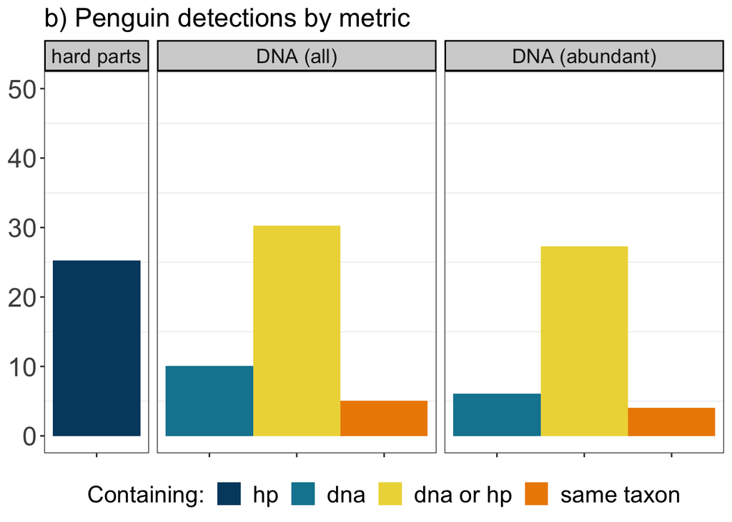

```r
#Figure 3b

#Relevel the method so that hard-part method comes first in the graph
#levels(penguin_sum_master$method)
penguin_sum_master$method <- factor(penguin_sum_master$method, levels = c("hard part", "DNA standard QC", "DNA stringent QC"))

#Relabel to clarify
penguin_sum_master$method <- factor(penguin_sum_master$method, levels = c("hard part", "DNA standard QC", "DNA stringent QC"), label = c("hard parts", "DNA (all)", "DNA (abundant)"))

#levels(penguin_sum_master$metric)
penguin_sum_master$metric <- factor(penguin_sum_master$metric, levels = c("hp", "dna", "dna_or_hp", "same_taxon"), label = c("hp", "dna", "dna or hp", "same taxon"))

#Figure 3b
fig3b_penguin <- ggplot(penguin_sum_master, aes(x=metric, y=Detected, fill=metric)) +
  geom_bar(stat="identity", position="dodge", width=1)+
  ggtitle("b) Penguin detections by metric")+
  theme_bw() +
  theme(panel.grid.major = element_blank(),
        plot.title=element_text(size=18), #face="bold",
        axis.title=element_blank(), #element_text(size=18)
        axis.text=element_text(size=18),
        axis.text.x=element_blank(),
        legend.text=element_text(size=16),
        legend.title=element_text(size=16),
        legend.position="bottom"
        ) +
  #theme(legend.position=c(0.60,0.80), legend.justification=c(0.4,0.5))+
  ylim(0,50)+
  scale_fill_manual(values=fig3.pal)+
  guides(fill=guide_legend(title="Containing:"))+
  labs(x=NULL, y="Percentage of samples (%)") + #x="Metric",
  facet_grid(.~method, scales="free",space='free') +
  theme(strip.text = element_text(size=rel(1.25)), #face="bold",
        strip.background = element_rect(fill="lightgrey", colour="black",
                                        size=1))
fig3b_penguin
```

```r
#ggsave(here('figures/Final versions/fig3b_penguin.jpeg'), plot = fig3b_penguin, width = 9, height = 5, dpi = 300)
```

**- Figure 3** - merges panels a and b, and displays the overall detection rates for seabirds and penguins according the method of scat analysis.

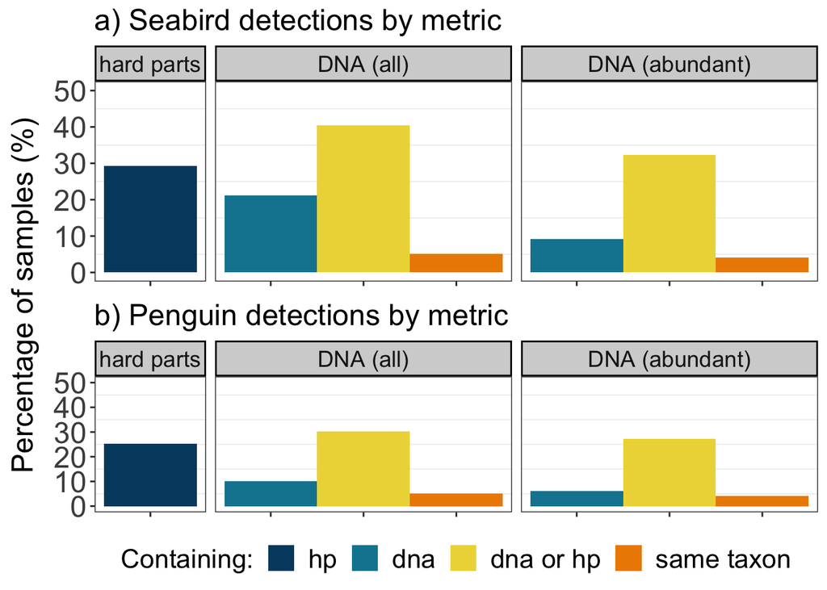

```r
#Merge the following plots into a single panel
#fig3a_bird & fig3b_penguin

#create common axis titles
y.grob <- textGrob("Percentage of samples (%)", gp=gpar(fontsize=18), rot=90) #fontface="bold", col="blue",
#x.grob <- textGrob("Percentage of samples containing remains (%)", gp=gpar(fontsize=18)) #fontface="bold", col="blue",

#combine using cowplot
fig3_panel = plot_grid(fig3a_bird, fig3b_penguin,
                       #align = "h",
                       nrow = 2
                          #labels = c("a) Seabirds", "b) Little penguins (Eudyptula minor)"),
                          #label_size = 18, ncol = 2,
                          #label_x = 0.20, label_y = 1, hjust = 0, vjust = 1.5,
                          #scale = 0.95,
                          #label_x = 0.10, vjust = 1, rel_widths = c(1, 1), align = "v",
                          #greedy = TRUE
                          ) #hjust = -7.5, label_x = c(0.12, 0.12, 0.12, 0.12, 0.12, 0.12)

#fig3_panel # check this

#add to plot
fig3_panel_ms = grid.arrange(arrangeGrob(fig3_panel, left = y.grob, padding = unit(1, "line")))
```

```r
#ggsave(here("figures/Final versions/fig3_panel_ms.jpeg"), plot = fig3_panel_ms, width = 10, height = 10, scale = 0.95, dpi = 300)

#ggsave(here("figures/Final versions/fig3_panel_ms.pdf"), plot = fig3_panel_ms, width = 10, height = 10, scale = 0.95, dpi = 300)
```

**- Figure 5a** depicts seabird percentage detections by location & time (using all DNA obtained through standard DNA QC)

```r
#Figure 5a
#Colour palette
fig5.pal <- pnw_palette(2, name = "Bay", type = "continuous")

#Need to exclude Deen Maar (LJP) in percentages

bird_master_group2 = bird_master_group %>%
  filter(location != "Deen Maar")

#Check & relevel factors as needed
l#evels(bird_master_group2$location)
bird_master_group2$location <- factor(bird_master_group2$location,
                                      levels = c("Cape Bridgewater", "Gabo Island", "Deen Maar", "Barunguba"),
                                      labels = c("Cape Bridgewater", "Gabo Isl.", "Deen Maar", "Barunguba"))

#levels(bird_master_group2$time_id)
```

```r
#Figure 5a
fig5a_bird <- ggplot(bird_master_group2, aes(x=time_id, y=percentage_detected, fill=metric)) +
  geom_bar(stat="identity",position="dodge")+
  coord_flip()+
  ylim(0,75)+
  theme_classic() +
  ggtitle("a) Seabird detections")+
  theme(panel.grid.major = element_blank(), plot.title=element_text(size=18),
        axis.title=element_blank(), axis.text=element_text(size=18),
        legend.text=element_text(size=16), legend.title=element_text(size=16)
        ) +
  #theme(axis.text.x=element_blank(), legend.position="top")+
  theme(legend.position=c(0.85,0.75), legend.justification=c(0.4,0.5))+
  scale_fill_manual(values=fig5.pal)+
  guides(fill=FALSE)+ #Remove legend for plotting alongside bird figure #guide_legend(title="Metric:")
  #labs(x="Sample time", y="Percentage of samples containing remains (%)") + #title ="a) Number of samples detecting seabirds",
  facet_grid(location~., scales="free", space='free') +
  theme(strip.text = element_text(size=rel(1.5)), #face="bold",
        strip.background = element_rect(fill="lightgrey", colour="black",
                                        size=1))
fig5a_bird

#ggsave(here('figures/Final versions/fig5a_bird_pdetect_location.jpeg'), plot = fig5a_bird, width = 8, height = 9, dpi = 300)
```

**- Figure 5b** depicts penguin percentage detections by location & time (using all DNA obtained through standard DNA QC)

```r
#Figure 5b
#Need to exclude Deen Maar in percentages
penguin_master_group2 = penguin_master_group %>%
  filter(location != "Deen Maar")

#levels(penguin_master_group2$location)

penguin_master_group2$location <- factor(penguin_master_group2$location,
                                         levels = c("Cape Bridgewater", "Gabo Island", "Deen Maar", "Barunguba"),
                                         labels = c("Cape Bridgewater", "Gabo Isl.", "Deen Maar", "Barunguba"))

levels(penguin_master_group2$time_id)

#Figure 5b
fig5b_penguin <- ggplot(penguin_master_group2, aes(x=time_id, y=percentage_detected, fill=metric)) +
  geom_bar(stat="identity",position="dodge")+
  coord_flip()+
  ylim(0,75)+
  theme_classic() +
  ggtitle("b) Little penguin (E. minor) detections")+
  theme(panel.grid.major = element_blank(), plot.title=element_text(size=18),
        axis.title=element_blank(), axis.text=element_text(size=18),
        legend.text=element_text(size=18), legend.title=element_text(size=18)
        ) +
  #theme(axis.text.x=element_blank(), legend.position="top")+
  theme(legend.position=c(0.85,0.85), legend.justification=c(0.4,0.5))+
  scale_fill_manual(values=fig5.pal)+
 guides(fill=guide_legend(title="Metric:"))+
  #labs(x="Sample time", y="Percentage of samples containing remains (%)") + #title ="a) Number of samples detecting seabirds",
  facet_grid(location~., scales="free", space='free') +
  theme(strip.text = element_text(size=rel(1.5)), #face="bold",
        strip.background = element_rect(fill="lightgrey", colour="black",
                                        size=1))

fig5b_penguin

#ggsave('figures/Final versions/fig5b_penguin_pdetect_location.jpeg', plot = fig5b_penguin, width = 8, height = 9, dpi = 300)
```

**- Figure 5** Includes both pannels for a) seabird and b) penguin percentage detections at sampling sites and seasons.

```r
#Merge the following plots into single panel plot
#fig5a_bird & fig5b_penguin

#create common axis titles
y.grob <- textGrob("Sample date", gp=gpar(fontsize=18), rot=90) #fontface="bold", col="blue",
x.grob <- textGrob("Percentage of samples containing remains (%)", gp=gpar(fontsize=18)) #fontface="bold", col="blue",

#combine using cowplot
bird_panel_ms = plot_grid(fig5a_bird, fig5b_penguin,
                           ncol = 2
                          #labels = c("a) Seabirds", "b) Little penguins (Eudyptula minor)"),
                          #label_size = 18, ncol = 2,
                          #label_x = 0.20, label_y = 1, hjust = 0, vjust = 1.5,
                          #scale = 0.95,
                          #label_x = 0.10, vjust = 1, rel_widths = c(1, 1), align = "v",
                          #greedy = TRUE
                          ) #hjust = -7.5, label_x = c(0.12, 0.12, 0.12, 0.12, 0.12, 0.12)

#add to plot
bird_panel_ms = grid.arrange(arrangeGrob(bird_panel_ms, left = y.grob, bottom = x.grob, padding = unit(1, "line")))

#ggsave(here("figures/Final versions/fig5_panel_ms.pdf"), plot = bird_panel_ms, width = 10, height = 10, scale = 0.95, dpi = 300)

#ggsave(here("figures/Final versions/fig5_panel_ms.jpeg"), plot = bird_panel_ms, width = 10, height = 10, scale = 0.95, dpi = 300)
```

**- Figure S3a** depicts seabird total (absolute) detections by location & time (using all DNA obtained through standard DNA QC) - for ESM.

```r
#Bird detections by location & time (standard DNA QC)
#For use in ESM

#Figure S2a
figS3a_bird <- ggplot(bird_master_group2, aes(x=time_id, y=detected, fill=metric)) +
  geom_bar(stat="identity",position="dodge")+
  coord_flip()+
  ylim(0,8)+
  ggtitle("a) Seabird detections")+
  theme_classic() +
  theme(panel.grid.major = element_blank(), plot.title=element_text(size=18),
        axis.title=element_blank(), axis.text=element_text(size=18),
        legend.text=element_text(size=16), legend.title=element_text(size=16),
        ) +
  #theme(axis.text.x=element_blank(), legend.position="top")+
  theme(legend.position=c(0.75,0.38), legend.justification=c(0.4,0.5))+
  scale_fill_manual(values=fig5.pal)+
  guides(fill=FALSE)+ #Remove legend for plotting alongside bird figure #guide_legend(title="Metric:")
  #guides(fill=guide_legend(title="Metric:"))+
  #labs(x="Sample time", y="Detections (number of samples containing remains)") + #title ="a) Number of samples detecting seabirds",
  facet_grid(location~., scales="free", space='free') +
  theme(strip.text = element_text(size=rel(1.5)), #face="bold",
        strip.background = element_rect(fill="lightgrey", colour="black",
                                        size=1))
figS3a_bird

#ggsave('figures/ESM/figS3a_birddetect_location.jpeg', plot = figS3a_bird, width = 8, height = 10, dpi = 300)
```

**- Figure S3b** depicts penguin total (absolute) detections by location & time (using all DNA obtained through standard DNA QC) - for ESM.

```r
#Penguin detections by location & time (standard DNA QC)
#For ESM

#Figure S3b
figS3b_penguin <- ggplot(penguin_master_group2, aes(x=time_id, y=detected, fill=metric)) +
  geom_bar(stat="identity",position="dodge")+
  coord_flip()+
  ylim(0,8)+
  ggtitle("b) Little penguin (E. minor) detections")+
  theme_classic() +
  theme(panel.grid.major = element_blank(),
        plot.title=element_text(size=18),
        axis.title=element_blank(),
        axis.text=element_text(size=18),
        legend.text=element_text(size=16),
        legend.title=element_text(size=16),
        ) +
  #theme(axis.text.x=element_blank(), legend.position="top")+
  theme(legend.position=c(0.75,0.38), legend.justification=c(0.4,0.5))+
  scale_fill_manual(values=fig5.pal)+
  guides(fill=guide_legend(title="Metric:"))+
  #guides(fill=FALSE)+ #Remove legend for plotting alongside bird figure #guide_legend(title="Metric:")
  #labs(x="Sample time", y="Detections (number of samples containing remains)") + #title ="a) Number of samples detecting seabirds",
  facet_grid(location~., scales="free", space='free') +
  theme(strip.text = element_text(size=rel(1.5)), #face="bold",
        strip.background = element_rect(fill="lightgrey", colour="black",
                                        size=1))

figS3b_penguin

#ggsave('figures/ESM/figS3b_penguin_detect_location.jpeg', plot = figS3b_penguin, width = 8, height = 10, dpi = 300)
```

**- Figure S3** Includes both panels for a) seabird and b) penguin total (absolute) detections at sampling sites and seasons. For ESM.

```r
#Merge the following plots into a single panel
#figS3a_bird & figS3b_penguin

#create common axis titles
yS1.grob <- textGrob("Sample date", gp=gpar(fontsize=18), rot=90) #fontface="bold", col="blue",
xS1.grob <- textGrob("Detections (number of samples containing remains)", gp=gpar(fontsize=18)) #fontface="bold", col="blue",

#combine using cowplot
figS3_panel_esm = plot_grid(figS3a_bird, figS3b_penguin,
                           ncol = 2)

#add to plot
bird_panel_esm = grid.arrange(arrangeGrob(figS3_panel_esm, left = yS1.grob, bottom = xS1.grob, padding = unit(1, "line")))

#ggsave("figures/ESM/figS3_bird_panel_esm.pdf", plot = bird_panel_esm, width = 14, height = 12, scale = 0.95, dpi = 300)

#ggsave("figures/ESM/figS3_bird_panel_esm.jpeg", plot = bird_panel_esm, width = 14, height = 12, scale = 0.95, dpi = 300)
```

### OTU figures

**- OTU palles** created to associated each taxon with a specific colour scheme throughout the OTU graphs.

```r
#Colour palette
figX.pal <- pnw_palette(9, name = "Sunset", type = "continuous")
show_col(figX.pal)

#Assign
#E. minor = "#41476B"
#Procellarid = "#825B75"
#Procellarid sp1 = "#A86972"
#Procellarid sp2 = "#C67B6F"
#"T. melanophris" = "#D89370"
#"S. bergii" = "#E6AB79"
#"M. serrator" = "#F2C48A"
#"Seabird unknown" = "#FBDFA2"

fig4a.pal <- c("#41476B", "#825B75", "#F2C48A", "#FBDFA2")
show_col(fig4a.pal)
fig4b.pal <- c("#41476B", "#A86972", "#C67B6F", "#D89370", "#E6AB79")
show_col(fig4b.pal)
```

**- Figure 4a** illustration of taxa detected (presence) within samples using hard-part analyses.

```r
#Colour palette #use fig4a.pal

#Graph with tick labels or without
fig4a_hptaxa = otu_hp_master %>%
  filter(detect > 0, method == "hard-parts") %>%
  #Manipulate data to include only samples that contained DNA
  ggplot() +
  geom_bar(aes(x=time_id:sample, y=detect, fill=Taxa), stat="identity", position="dodge")+
  #scale_y_discrete(breaks= NULL) +
  coord_flip()+
  theme_classic() +
  theme(panel.grid.major = element_blank(),
        axis.ticks = element_blank(),
        plot.title=element_text(size=18), #face="bold",
        #axis.title.x=element_text(size=18),
        axis.title.y=element_blank(),
        axis.text=element_text(size=18),
        axis.text.x=element_blank(),
        legend.text=element_text(size=18),
        legend.title=element_text(size=18)
        ) +
  theme(legend.position=c(0.20,0.10), legend.justification=c(0.5,0.5)) +
  scale_fill_manual(values=fig4a.pal, name="Taxa:") +
  labs(title ="a) Hard-part detections", y = "") +
  #x="Individual sample & Sampling time", y="Presence of seabird remains in samples"
  facet_grid(location~., scales="free", space='free') +
  theme(strip.text = element_text(size=rel(1.5)), #face="bold",
        strip.background = element_rect(fill="lightgrey", colour="black",
                                        size=1))

fig4a_hptaxa

#ggsave('figures/Final versions/fig4a_hptaxa_RRA_label.pdf', plot = fig4a_hptaxa, width = 12, height = 12, dpi = 300)
```

```r
### Figure 4b dna detections seabird presence/absence
fig4b_dna_detect = otu_hp_master %>%
  filter(detect > 0, method == "DNA standard QC") %>%
  ggplot() +
  geom_bar(aes(x=time_id:sample, y=detect, fill=Taxa), stat="identity", position="dodge")+
  coord_flip()+
  theme_classic() +
  theme(panel.grid.major = element_blank(),
        axis.ticks = element_blank(),
        plot.title=element_text(size=18), #face="bold",
        #axis.title.x=element_text(size=18),
        axis.title.y=element_blank(),
        axis.text=element_text(size=18),
        axis.text.x=element_blank(),
        legend.text=element_text(size=18),
        legend.title=element_text(size=18)
        ) +
  theme(legend.position=c(0.20,0.10), legend.justification=c(0.5,0.5)) +
  scale_fill_manual(values=fig4b.pal, name="Taxa:")+
  #guides(fill=guide_legend(title=))+
  labs(title ="b) DNA-based detections", y = "") + # Axis labels
  #, y="Presence of seabird remains in samples"
  facet_grid(location~., scales="free", space='free') +
  theme(strip.text = element_text(size=rel(1.5)), #face="bold",
        strip.background = element_rect(fill="lightgrey", colour="black",
                                        size=1))
fig4b_dna_detect

#ggsave('figures/Final versions/fig4b_dna_detect.pdf', plot = fig4b_dna_detect, width = 12, height = 12, dpi = 300)
```

**- Figure 4** panel illustration of taxa detected (presence) within samples using a) hard-part and b) DNA-based analyses.

```r
#Need the following plots
#fig4a_hptaxa and fig4b_dna_detect

#create common axis titles
y4.grob <- textGrob("Sample date: sample number", gp=gpar(fontsize=20), rot=90) #fontface="bold", col="blue",
x4.grob <- textGrob("Presence of seabird taxa in samples", gp=gpar(fontsize=20)) #fontface="bold", col="blue",

#Combine plots
fig4_panel_test=grid.arrange(fig4a_hptaxa, #+  theme(legend.position=c(0.5, 0.90)
                        fig4b_dna_detect, #+ theme(legend.position=c(0.5, 0.90))
                        #fig4c_otu_abun + theme(legend.position=c(0.5, 0.90)), #put in ESM Fig. S1
                        nrow=1)

fig4_panel_ms = grid.arrange(arrangeGrob(fig4_panel_test, left = y4.grob, bottom = x4.grob, padding = unit(1, "line")))

#ggsave("figures/Final versions/fig4_panel.pdf", plot = fig4_panel_ms, width = 20, height = 14, scale = 0.95, dpi = 300)

#ggsave("figures/Final versions/fig4_panel.jpeg", plot = fig4_panel_ms, width = 20, height = 14, scale = 0.95, dpi = 300)
```

**- Figure S1** illustration of taxa detected using DNA-based analyses and their total sequence abundance within samples. For ESM.

```r
#Can exclude samples containing < 40 seqs or other cut-off if needed
#test = otu_hp_master %>%
#  filter(seq_abun >= 40, method == "DNA standard QC")

#Figure S1 - most abundant sequences
figS1_otu_abun = otu_hp_master %>%
  filter(seq_abun > 1, method == "DNA standard QC") %>%
  mutate(trace_high = factor(if_else(seq_abun >= 30, "high", "trace"), levels = c("trace", "high"))) %>% #Add trace vs. high DNA abundance
  ggplot() +
  geom_bar(aes(x=time_id:sample, y=seq_abun, fill=Taxa), stat="identity", position = "dodge", width = 0.75) +
  coord_flip() +
  theme_classic() +
  theme(panel.grid.major = element_blank(),
        axis.ticks.y = element_blank(),
        plot.title=element_text(size=18), #face="bold",
        axis.title.x=element_text(size=18),
        axis.title.y=element_text(size=18),
        axis.text=element_text(size=18), #axis.text.y=element_blank(),
        legend.text=element_text(size=18),
        legend.title=element_text(size=18)
        ) +
  theme(legend.position=c(0.75,0.90), legend.justification=c(0.5,0.5)) +
#  theme(legend.position=c(0.20,0.10), legend.justification=c(0.5,0.5)) +
  scale_fill_manual(values=fig4b.pal, name="Taxa:") +
  #guides(fill=guide_legend(title=))+
  labs(x="Sample date: sample number", y="Total sequence abundance (n)") + # Axis labels #title ="c) Abundance of DNA detected",
  facet_grid(location ~ trace_high, scales="free", space='free_y') +
  theme(strip.text = element_text(size=rel(1.5)), #face="bold",
        strip.background = element_rect(fill="lightgrey", colour="black",
                                        size=1))
figS1_otu_abun

#Save as jpeg
#ggsave('figures/ESM/figS1_otu_abun.pdf', plot = figS1_otu_abun, width = 12, height = 12, dpi = 300)
#In pdf:
#Need to italicise a portion of species names
```

**- Figure SX** not included in MS or ESM - this was to illustrate the relative contribution of seabirds to each sample in relation to the DNA abundance recovered across the total.

```r
#Figure X - extra
figSX_otu_RRA <- otu_hp_master %>%
  filter(seq_abun >= 1, method == "DNA standard QC") %>%
  ggplot() +
  geom_bar(aes(x=time_id:sample, y=seq_prop, fill=Taxa), stat="identity") +
  #ggplot(otu_med_abundant, aes(x=time_id:sample_id, y=seq_prop, fill=OTU)) +
  #geom_bar(stat="identity",position="dodge")+
  coord_flip()+
  theme_classic() +
  theme(panel.grid.major = element_blank(),
        axis.ticks.y = element_blank(),
        plot.title=element_text(face="bold", size=18),
        axis.title=element_text(size=18),
        axis.text=element_text(size=18),
        #axis.text.y=element_blank(),
        legend.text=element_text(size=16),
        legend.title=element_text(size=16)#,
        #legend.position="top"
        ) +
  theme(legend.position=c(0.75,0.25), legend.justification=c(0.4,0.5))+
  scale_fill_manual(values=fig4b.pal, name="Taxa:")+
  labs(x="Individual sample / Sampling time", y="Relative DNA abudance (%)") + # Axis labels
  #title ="a) Total sequence abundance (n) of seabirds across samples and locations",
  #facet_zoom(ylim = c(0, 5))+
  facet_grid(location~., scales="free", space='free') +
  theme(strip.text = element_text(size=rel(1.5)), #face="bold",
        strip.background = element_rect(fill="lightgrey", colour="black",
                                        size=1))
figSX_otu_RRA

#ggsave('figures/ESM/figSX_otu_totalRA.pdf', plot = figSX_otu_RRA, width = 8, height = 12, dpi = 300)
```

**- Figure S2** to illustrate the proportional abundance of sequences per taxon per sample, also known as the relative rea abundance (Thomas & Deagle, et al. 2019). For ESM.

```r
## We want a graph displaying the proportional abundance of sequences per sample, with time on the x-axis and proportion on the y-axis
## Similar to my excel mock-up graph

#Manipulate data

otu_rra = otu_metrics %>%
  separate(sample_id, c("loc", "month", "year", "sample")) %>%
  select(location:prop_abun) %>%
  #mutate(seq_pa = if_else(seq_abun > 0, 1, 0)) %>%
  filter(seq_abun > 1)

otu_rra$sample <- as.factor(otu_rra$sample)

#Graph with tick labels or without

figS2_otu_RRA = otu_rra %>%
  ggplot() +
  geom_bar(aes(x=time_id:sample, y=prop_abun, fill=OTU), stat="identity")+
  coord_flip()+
  theme_classic() +
  theme(panel.grid.major = element_blank(),
        axis.ticks.y = element_blank(),
        plot.title=element_text(face="bold", size=18),
        axis.title=element_text(size=18),
        axis.text=element_text(size=18),
        legend.text=element_text(size=16),
        legend.title=element_text(size=16),
        legend.position="top"
        ) +
  scale_fill_manual(values=fig4b.pal, name="Taxa:")+
  labs(x="Sample date: sample number", y="Relative DNA abundance (%)") + # Axis labels
  facet_grid(location~., scales="free", space='free') +
  theme(strip.text = element_text(size=rel(1.5)), #face="bold",
        strip.background = element_rect(fill="lightgrey", colour="black",
                                        size=1))
figS2_otu_RRA

#ggsave('figures/ESM/figS2_otu_RRA.pdf', plot = figS2_otu_RRA, width = 12, height = 12, dpi = 300)
```

**- Figure 7** Little penguin haplotype diversity within samples containing DNA for little penguin (n = 10), using the primer for 12S rRNA gene. The genetic abundance of haplotypes identified is overlaid. Each haplotype within a sample represents an individual penguin consumed.

```r
#Little penguin haplotype presence in samples, including haplotype abundance data

#Colour palette
fig7.pal <- pnw_palette(8, name = "Sunset", type = "continuous")

## We want a graph displaying the proportional abundance of sequences per sample, with time on the x-axis and proportion on the y-axis
## Similar to my excel mock-up graph

fig7_haplo_presence = penguin_haplos_sample %>%
  #penguin_haplos %>%
  filter(seq_abun > 1) %>%
  ggplot(aes(x=time_id:sample, y=seq_presence, fill=haplotype)) +
  coord_flip()+
  geom_bar(stat="identity")+
  geom_text(aes(label=seq_abun,
                #vjust=0,
                #hjust=2
                ),
            colour="white",
            size=6,
            position = position_stack(vjust = 0.5)) + #xlab("")
  theme_classic() +
  theme(panel.grid.major = element_blank(),
        axis.ticks.x = element_blank(),
        plot.title=element_text(face="bold", size=18),
        axis.title=element_text(size=18),
        axis.text.y =element_text(size=18),
        axis.text.x =element_blank(),
        legend.text=element_text(size=16),
        legend.title=element_text(size=16),
        legend.position="top"
        ) +
  scale_fill_manual(values=figS3.pal, name="Haplotype:")+
  labs(x="Sample date: sample number", y="Little penguin haplotypes & sequence abundance") + # Axis labels
  facet_grid(location~., scales="free", space='free') +
  theme(strip.text = element_text(size=rel(1.5)), #face="bold",
        strip.background = element_rect(fill="lightgrey", colour="black",
                                        size=1))
fig7_haplo_presence

#ggsave(here('figures/Final versions/fig7_haplo_presence.pdf'), plot = fig7_haplo_presence, width = 10, height = 10, dpi = 300)

#ggsave(here('figures/Final versions/fig7_haplo_presence.jpg'), plot = fig7_haplo_presence, width = 10, height = 10, dpi = 300)
```

**- Figure 7X** Extra graph - bubble graph version of above - Little penguin haplotype diversity within samples containing DNA for little penguin (n = 10), using the primer for 12S rRNA gene. The genetic abundance of haplotypes identified is overlaid. Each haplotype within a sample represents an individual penguin consumed.

```r
#Here we want to make a bubble plot

figS4_haplo_bubble = penguin_haplos %>%
  filter(seq_abun > 1) %>%
  ggplot(aes(x=time_id:sample_id, y=seq_presence, fill=haplotype, colour=haplotype, size=seq_abun)) + #,
  geom_point(position="stack") +
  geom_text(aes(label=seq_abun, #rev(seq_abun) this appeared to completely reorder the seq data all over the graph
                #vjust=0.5,
                #hjust=2
                ),
            #colour="#333333",
            colour="white",
            size=6,
            position = position_stack(vjust = 1)) +
  coord_flip() +
  theme_classic() +
  theme(panel.grid.major = element_blank(),
        axis.ticks.x = element_blank(),
        plot.title=element_text(face="bold", size=18),
        axis.title=element_text(size=18),
        axis.text.y =element_text(size=18),
        axis.text.x =element_blank(),
        legend.text=element_text(size=16),
        legend.title=element_text(size=16),
        legend.position="top") +
  scale_fill_manual(values=figS3.pal, name="Haplotype:")+
  scale_colour_manual(values=figS3.pal, name="Haplotype:")+
  scale_size(range = c(12, 32),
             guide=FALSE) +
  guides(colour = guide_legend(override.aes = list(size=10)))+
  labs(x="Sample date: sample number", y="Little penguin haplotypes & sequence abundance") + # Axis labels
  facet_grid(location~., scales="free", space='free') +
  theme(strip.text = element_text(size=rel(1.5)), #face="bold",
        strip.background = element_rect(fill="lightgrey", colour="black",
                                        size=1))
figS4_haplo_bubble

#ggsave(here('figures/ESM/figS4_haplo_bubble.pdf'), plot = figS4_haplo_bubble, width = 10, height = 10, dpi = 300)
```

## Statistical Analyses

We aim to test the hypothesis that bird or penguin detections will vary using different methods and combinations of these methods (here referred to as “metric”). Experimental design/formula, as a minimum: detection ~ metric These data are binomial and seem to have violated assumptions for simpler tests + ANOVA. So we are running a binomial regression (glm with family=binomial) How to incorporate the group_id, location or time for this? Note that for each group_id we have replication of each treatment (metric) value being DNA or HP method used. Location and time are effective random.

The Analysis Factor have some simple reminders about how to treat factors –> comes down to our explicit hypotheses. https://www.theanalysisfactor.com/the-difference-between-crossed-and-nested-factors/

Here we subset the dataframe as needed for analyses.

```r
#Data distributions
dotchart(bird_med$detection)

#Histogram
hist(bird_med$detection)

#Exclude LJP (Deen Maar) from analyses, as well as stringent QC because we don't want to compare that.

bird_master_test = bird_master %>%
  select(location, time_id, group_id, metric, method, detection) %>%
  dplyr::filter(metric == c('hp', 'dna'), location != "Deen Maar", method != "DNA stringent QC")

penguin_master_test = penguin_master %>%
  select(location, time_id, group_id, metric, method, detection) %>%
  dplyr::filter(metric == c('hp', 'dna'), location != "Deen Maar", method != "DNA stringent QC")

#Relevelling factors: we logically want CB Sept_15 to be the reference point because it is the earliest time point
levels(bird_master_test$group_id)
bird_master_test$group_id <- factor(bird_master_test$group_id, levels = c("CB_Sep_15","CB_Jan_16","CB_Sep_16","CB_Jan_17","GI_Jan_17","LJP_Mar_17", "MI_Sep_16", "MI_Jan_17"))

levels(penguin_master_test$group_id)
penguin_master_test$group_id <- factor(penguin_master_test$group_id, levels = c("CB_Sep_15","CB_Jan_16","CB_Sep_16","CB_Jan_17","GI_Jan_17","LJP_Mar_17", "MI_Sep_16", "MI_Jan_17"))
```

### BIRD MODELS

The interaction term was not significant (p > 0.07), and whilst small, there were no significant pairwise interactions, we therefore remove this term from the model.

```r
#Bird binomial GLMs for detection of birds ~ metric * sample group
bird_model_1 <- glm(detection ~ metric*group_id, family = binomial, data = bird_master_test)
anova(bird_model_1, test = "Chisq")
summary(bird_model_1)

#Output for bird_model_med

#Analysis of Deviance Table
#Model: binomial, link: logit
#Response: detection
#Terms added sequentially (first to last)
#                Df Deviance Resid. Df Resid. Dev Pr(>Chi)
#NULL                               99    114.611
#metric           1   0.2081        98    114.403  0.64829
#group_id         6  15.4554        92     98.948  0.01700 *
#metric:group_id  6  11.5098        86     87.438  0.07384 .

##UPDATE STILL NS

#Call:
#glm(formula = detection ~ metric * group_id, family = binomial, data = bird_master_test)
#Deviance Residuals:
#     Min        1Q    Median        3Q       Max
#-1.01077  -0.84460  -0.51678  -0.00022   2.44775
#Coefficients:
#                             Estimate Std. Error z value Pr(>|z|)
#(Intercept)                   -0.5108     0.7303  -0.699    0.484
#metricdna                     -0.2776     0.9079  -0.306    0.760
#group_idCB_Jan_17             -0.8755     1.0763  -0.813    0.416
#group_idCB_Sep_15             18.0769  1978.0903   0.009    0.993
#group_idCB_Sep_16             -1.2809     1.3038  -0.982    0.326
#group_idGI_Jan_17             -1.0986     1.3166  -0.834    0.404
#group_idMI_Jan_17              0.1054     1.1690   0.090    0.928
#group_idMI_Sep_16             -1.6864     1.2824  -1.315    0.188
#metricdna:group_idCB_Jan_17    0.8166     1.2990   0.629    0.530
#metricdna:group_idCB_Sep_15  -19.2343  1978.0907  -0.010    0.992
#metricdna:group_idCB_Sep_16    0.7701     1.5541   0.496    0.620
#metricdna:group_idGI_Jan_17  -15.6790  1142.0518  -0.014    0.989
#metricdna:group_idMI_Jan_17    0.2776     1.4402   0.193    0.847
#metricdna:group_idMI_Sep_16   -0.4696     1.7286  -0.272    0.786
#(Dispersion parameter for binomial family taken to be 1)
#    Null deviance: 160.57  on 149  degrees of freedom
#Residual deviance: 131.26  on 136  degrees of freedom
#AIC: 159.26
#Number of Fisher Scoring iterations: 16
```

There was a significant effect of time/space (group_id) on seabird detections. Note that is was GI, MI Sep 16 that drove these overall – being low detection values.

```r
#Relevel factors to double check significance terms
levels(bird_master_test$group_id)
bird_master_test$group_id <- factor(bird_master_test$group_id, levels = c("CB_Sep_15", "CB_Jan_16", "CB_Sep_16", "CB_Jan_17", "GI_Jan_17",  "LJP_Mar_17", "MI_Sep_16",  "MI_Jan_17"))

bird_model_2 <- glm(detection ~ metric+group_id, family = binomial, data = bird_master_test)
anova(bird_model_2, test = "Chisq")
summary(bird_model_2)

#Analysis of Deviance Table
#Model: binomial, link: logit
#Response: detection
#Terms added sequentially (first to last)
#         Df Deviance Resid. Df Resid. Dev Pr(>Chi)
#NULL                        99    114.611
#metric    1   0.2081        98    114.403   0.6483
#group_id  6  15.4554        92     98.948   0.0170 *

#UPDATED SUMMARY CALL
#Call:
#glm(formula = detection ~ metric + group_id, family = binomial, data = bird_master_test)

#Deviance Residuals:
#    Min       1Q   Median       3Q      Max
#-1.3474  -0.8822  -0.3923   0.9225   2.4029

#Coefficients:
#                  Estimate Std. Error z value Pr(>|z|)
#(Intercept)         0.6342     0.7746   0.819  0.41290
#metricdna          -0.2431     0.4940  -0.492  0.62266
#group_idCB_Jan_16  -1.3039     0.9096  -1.433  0.15172
#group_idCB_Sep_16  -1.8162     0.9803  -1.853  0.06394 .
#group_idCB_Jan_17  -1.1339     0.8695  -1.304  0.19218
#group_idGI_Jan_17  -2.9167     1.2761  -2.286  0.02227 *
#group_idMI_Sep_16  -3.4638     1.2608  -2.747  0.00601 **
#group_idMI_Jan_17  -0.9196     0.9765  -0.942  0.34631
#---
#Signif. codes:  0 ‘***’ 0.001 ‘**’ 0.01 ‘*’ 0.05 ‘.’ 0.1 ‘ ’ 1

#(Dispersion parameter for binomial family taken to be 1)

#    Null deviance: 114.611  on 99  degrees of freedom
#Residual deviance:  98.948  on 92  degrees of freedom
#AIC: 114.95
#Number of Fisher Scoring iterations: 5
```

```r
#Model 1b validation
plot(bird_model_2)
#Montague Island September 2016 were influential/outlier data points

#Or:
E2 <- resid(bird_model_2, type = "pearson")
F2 <- fitted(bird_model_2)
plot(x = F2,
     y = E2,
     xlab = "Fitted values",
     ylab = "Residuals")
#Some fanning happening

#Influential observations
plot(bird_model_2, which = c(4)) #note some influential values

par(mfrow=c(1,1))
plot(cooks.distance(bird_model_2),
     type = "h",
     ylim = c(0,1))
abline(h=1)

#Normality
hist(E2, breaks = 15)
#Data are not normal

#Independence:
#For group id --> variance heterogeneous
plot(x = bird_master_test$group_id,
     y = E2,
     xlab = "Group ID",
     ylab = "Residuals")

#For method --> there is homogeneity of variance
#plot(x = bird_master_test$method,
#     y = E2,
#     xlab = "Group ID",
#     ylab = "Residuals")

#Per period:
#xyplot(E2 ~ method | factor(group_id),
#       data = bird_master_test,
#       panel = function(x,y){
#         panel.points(x,y, col = 1, pch = 16, cex = 0.7)
#         panel.loess(x,y, col = 1, lwd = 2)
#         panel.abline(h=0)
#       })

#boxplot(E2 ~ Period, data = bird_master_test)
```

### PENGUIN MODELS

The interaction term was not significant p > 0.25, so we will remove the interaction term.

```r
#Penguin binomial GLMs for detection of birds ~ metric * sample group
str(penguin_master_test)
penguin_model_1 <- glm(detection ~ metric*group_id, family = binomial, data = penguin_master_test)
anova(penguin_model_1, test = "Chisq")

#Model: binomial, link: logit
#Response: detection
#Terms added sequentially (first to last)
#                Df Deviance Resid. Df Resid. Dev Pr(>Chi)
#NULL                               99     97.245
#metric           1   1.6403        98     95.604   0.2003
#group_id         6   8.1254        92     87.479   0.2291
#metric:group_id  6   6.2432        86     81.236   0.3965

#Remove interaction term as p > 0.25
```

There was no significant effect of metric or time/space on the levels of detection of penguins within samples.

```r
penguin_model_2 <- glm(detection ~ metric + group_id, family = binomial, data = penguin_master_test)
anova(penguin_model_2, test = "Chisq")
#summary(penguin_model_2)

##UPDATE
#         Df Deviance Resid. Df Resid. Dev Pr(>Chi)
#NULL                        99     97.245
#metric    1   1.6403        98     95.604   0.2003
#group_id  6   8.1254        92     87.479   0.2291
```